# ANALISI DATASET “NATIONAL LIFE EXPECTANCIES”

##### Progetto d’esame conclusivo del corso di studi in Data Analytics anno 2023/2024 a cura di

##### Bortolussi Lorenzo Bosco Francesco Bredariol Francesco Tonet Lorenzo

## Introduzione

##### descrizione del dataset e definizione dell’obiettivo dell’analisi

### Descrizione Dataset

Il nostro dataset, “National Life Expectancies”, è un dataset che contiene informazioni riguardo 185 Paesi nel Mondo. Queste informazioni passano da semplici descrizioni demografiche sino a dettagli geopolitici e la loro natura è quasi completamente numerica, poiché questi dati sono per lo più indici e percentuali.  
La fonte dei dati è lo “United Nations Human Development Report”.

### Obiettivo Analisi

Partendo dai dati in nostro possesso la nostra analisi ha l’obiettivo di trovare le relazioni più forti all’interno del dataset avendo come variabile target l’indice “Aspettativa di Vita”. Questa ricerca di relazioni sarà preceduta dall’analisi delle singole variabili per poter ottenere a priori informazioni che potrebbero poi rivelarsi importanti. Obiettivo ultimo sarà quello di raggruppare i paesi in cluster di “benessere di vita” sfruttando le informazioni desunte dal lavoro svolto in precedenza.

## Variabili Dataset

##### descrizione variabili dataset e prime osservazioni

### Descrizioni Variabili

Andiamo a descrivere le singoli variabili, visualizzandone nome, numero di osservazioni mancanti ed una breve descrizione

| VARIABILE | OSSERVAZIONI MANCANTI | DESCRIZIONE |
| --- | --- | --- |
| **REGION** | 0 | Variabile categoriale che indica una regione associata |
| **COUNTRY** | 0 | Nome del Paese |
| **LIFEEXP** | 0 | Aspettativa di vita dalla nascita misurata in anni |
| **ILLITERATE** | 14 | Tasso di analfabetismo percentuale negli adulti (età > 15 anni) |
| **POP** | 1 | Popolazione nel 2005 in milioni di abitanti |
| **FERTILITY** | 4 | Tasso di fertilità, nascite per donna |
| **PRIVATEHEALTH** | 1 | Spesa sanità 2004 misurata in %GDP |
| **PUBLICEDUCATION** | 28 | Spesa educazione misurata in %GDP |
| **HEALTHEXPEND** | 5 | Spesa sanitaria pro capite 2004 misura in USD |
| **BIRTHATTEND** | 7 | % Nascite assistite da personale specializzato |
| **PHYSICIAN** | 3 | Medici per 100,000 abitanti |
| **SMOKING** | 88 | % Fumatori maschi adulti |
| **REASEARCHERS** | 95 | Ricercatori in Ricerca e Sviluppo per Milioni di abitanti |
| **GDP** | 7 | Prodotto Interno Lordo in miliardi di USD |
| **FEMALEBOSS** | 87 | % di donne con posizioni di dirigenza |

### Osservazioni

Notiamo subito che sarà per noi necessaria la gestione delle osservazioni mancanti. Per esempio dobbiamo decidere come trattare la variabile “FEMALEBOSS” che ha un tasso di NA prossimo al 50%. Nel prossimo paragrafo ci soffermeremo dunque su questo aspetto e sulla scelta della fattorizzazione di alcune variabili quali potrebbero essere REGION.

## Bonifica dei dati

##### gestione NA e fattorizzazione

La primissima operazione da compiere sarà il caricamento dei dati da file CSV. Per comodità abbiamo nominato il file “life expectation.csv”. Nella lettura ci ricordiamo di settare header = TRUE. Eseguiamo subito una summary per poter trarre le prime conclusioni.

Prepariamo il nostro ambiente R importando le librerie necessarie e definendo dei colori utili alla visualizzazione dei grafici

```r
library(patchwork)
library(ggplot2)
library(ggExtra)
library(moments)
library(sf)
library(rnaturalearth)
library(dplyr)
library(corrplot)
library(MASS)
set.seed(1235)

verde_acqua = "#64F9C7"
giallo = "#FFFF00"
arancione = "#FFB600"
verde_acqua_scurito = "#3da07f"
arancione_scurito = "#D69A01"
black ="#000000"

col_map = c("1" = "#64F9C7", "2" = "#FFFF00", "3" = "#FFB600", "4" = "#ee6055", "5" = "#57f054", "6" = "#c73596", "7" = "#a26769", "8" = "#7ca5b8")
```

```r
data = read.csv("life expectation.csv", header = TRUE)
original_data = data
summary(data)
```

```
##      REGION        COUNTRY             LIFEEXP        ILLITERATE
##  Min.   :1.000   Length:185         Min.   :40.50   Min.   : 0.20
##  1st Qu.:3.000   Class :character   1st Qu.:59.70   1st Qu.: 1.35
##  Median :6.000   Mode  :character   Median :71.00   Median :10.10
##  Mean   :4.692                      Mean   :67.05   Mean   :17.69
##  3rd Qu.:7.000                      3rd Qu.:75.10   3rd Qu.:27.50
##  Max.   :8.000                      Max.   :82.30   Max.   :76.40
##                                                     NA's   :14
##       POP            FERTILITY    PRIVATEHEALTH   PUBLICEDUCATION
##  Min.   :   0.10   Min.   :0.90   Min.   :0.300   Min.   : 0.600
##  1st Qu.:   2.45   1st Qu.:1.80   1st Qu.:1.500   1st Qu.: 3.400
##  Median :   7.80   Median :2.70   Median :2.400   Median : 4.600
##  Mean   :  35.36   Mean   :3.19   Mean   :2.517   Mean   : 4.695
##  3rd Qu.:  23.60   3rd Qu.:4.30   3rd Qu.:3.300   3rd Qu.: 5.800
##  Max.   :1313.00   Max.   :7.50   Max.   :8.500   Max.   :13.400
##  NA's   :1         NA's   :4      NA's   :1       NA's   :28
##   HEALTHEXPEND     BIRTHATTEND       PHYSICIAN         SMOKING
##  Min.   :  15.0   Min.   :  6.00   Min.   :  2.00   Min.   : 6.00
##  1st Qu.: 100.5   1st Qu.: 61.00   1st Qu.: 21.25   1st Qu.:24.00
##  Median : 297.5   Median : 92.00   Median :107.50   Median :32.00
##  Mean   : 718.0   Mean   : 78.25   Mean   :146.08   Mean   :35.09
##  3rd Qu.: 727.0   3rd Qu.: 99.00   3rd Qu.:247.00   3rd Qu.:47.00
##  Max.   :6096.0   Max.   :100.00   Max.   :591.00   Max.   :68.00
##  NA's   :5        NA's   :7        NA's   :3        NA's   :88
##   RESEARCHERS           GDP             FEMALEBOSS
##  Min.   :   15.0   Min.   :    0.10   Min.   : 2.00
##  1st Qu.:  127.2   1st Qu.:    3.55   1st Qu.:23.25
##  Median :  848.0   Median :   14.20   Median :30.00
##  Mean   : 2034.7   Mean   :  247.55   Mean   :29.07
##  3rd Qu.: 2538.0   3rd Qu.:  109.28   3rd Qu.:36.75
##  Max.   :45454.0   Max.   :12416.50   Max.   :58.00
##  NA's   :95        NA's   :7          NA's   :87
```

## Fattorizzazione

##### COUNTRY

Il summary ci evidenzia subito come la variabile COUNTRY sia un character e per questo motivo decidiamo di trattarla come factor. Dobbiamo sottolineare tuttavia che questa variabile non ha alcun valore duplicato e possiamo già dedurre che non è di rilievo ai fini della nostra analisi. Potrebbe essere interessante trasformare questa variabile fattoriale in una variabile di tipo “posizione geografica”, tuttavia decidiamo di sfruttare a questo fine la variabile REGION.

```r
data$COUNTRY = factor(data$COUNTRY)
```

##### REGION

REGION è una variabile che descrive l’appartenenza dei Paesi a cluster geografici ed è questo il motivo per cui decidiamo di convertirla a factor.

```r
data$REGION = factor(data$REGION)
```

## Gestione NA

Per quanto riguarda gli NA decidiamo di eseguire un approccio in base alla percentuale di quest’ultimi e al tipo di analisi da eseguire. Nei casi delle analisi univariate rimuoviamo gli NA; nei casi delle analisi bivariate valutiamo la percentuale di NA della seconda variabile (ricordiamo che la variabile target da noi considerata è sempre LIFEEXPECT): in caso questa sia troppo alta (>30%) non riterremo l’analisi attendibile e quindi la eviteremo, mentre se questa sarà sufficientemente bassa (<30%) rimuoveremo semplicemente le righe che presentano gli NA.  
Il codice non verrà presentato ora poiché sarà nelle singole analisi che verrà effettuato questo passaggio di pulizia. Diamo comunque uno sguardo alla distribuzione degli NA, nel nostro dataset.

Otteniamo una tabella in cui vengono indicati, in base al paese, quanti NA sono presenti per ogni variabile

```r
country_na_counts = original_data %>%
  group_by(COUNTRY) %>%
  summarise(across(everything(), ~sum(is.na(.))))

country_na_counts
```

```
## # A tibble: 185 × 15
##    COUNTRY             REGION LIFEEXP ILLITERATE   POP FERTILITY PRIVATEHEALTH
##    <chr>                <int>   <int>      <int> <int>     <int>         <int>
##  1 Afghanistan              0       0          0     0         0             0
##  2 Albania                  0       0          0     0         0             0
##  3 Algeria                  0       0          0     0         0             0
##  4 Angola                   0       0          0     0         0             0
##  5 Antigua�and�Barbuda      0       0          0     0         1             0
##  6 Argentina                0       0          0     0         0             0
##  7 Armenia                  0       0          0     0         0             0
##  8 Australia                0       0          0     0         0             0
##  9 Austria                  0       0          0     0         0             0
## 10 Azerbaijan               0       0          0     0         0             0
## # ℹ 175 more rows
## # ℹ 8 more variables: PUBLICEDUCATION <int>, HEALTHEXPEND <int>,
## #   BIRTHATTEND <int>, PHYSICIAN <int>, SMOKING <int>, RESEARCHERS <int>,
## #   GDP <int>, FEMALEBOSS <int>
```

Otteniamo la somma degli NA per paese e visualiziamone la testa della classifica.

```r
country_na_counts = original_data %>%
  group_by(original_data$COUNTRY) %>%
  summarise(Total_NA = sum(rowSums(is.na(across(-COUNTRY)))))

country_na_counts = country_na_counts[order(country_na_counts$Total_NA, decreasing=TRUE), ]
country_na_counts
```

```
## # A tibble: 185 × 2
##    `original_data$COUNTRY`             Total_NA
##    <chr>                                  <dbl>
##  1 Somalia                                    7
##  2 Hong�Kong�China�(SAR)                      5
##  3 Korea�(Democratic�People's�Rep.�of)        5
##  4 Occupied�Palestinian�Territories           5
##  5 Saint�Kitts�and�Nevis                      5
##  6 Afghanistan                                4
##  7 Comoros                                    4
##  8 Congo�(Democratic�Republic�of�the)         4
##  9 Cuba                                       4
## 10 Djibouti                                   4
## # ℹ 175 more rows
```

## REGION

##### studio della suddivisione regionale

La prima analisi che andiamo ad effettuare, in maniera mirata, è l’analisi della composizione della variabile REGION. Il motivo di questa scelta è che, prima ancora di studiare la variabile, vogliamo comprendere come sono stati raggruppati i vari Paesi per poter comprendere se ci saranno comportamenti di gruppo giustificabili dalla REGION di appartenenza. Questo potrebbe poi portarci, nel caso, a studiare alcuni risultati a livello regionale anziché a livello statale, poiché questo può rendere più comprensibile il risultato dell’analisi se il comportamento statale presenta una variabilità troppo alta.

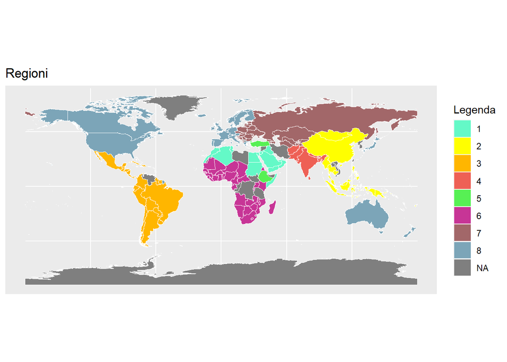

Scopriamo che non è stata effettuata una suddivsione totalmente geografica. In particolare sono le regioni 5 ed 8 ad essere non contigue, e immaginiamo dunque il motivo possa essere la struttura dell’organizzazione che raccoglie i dati. Comunque sia ora abbiamo uno sguardo più conscio sulla struttura della variabile REGION e questo ci potrà sicuramente aiutare in futuro.

## Analisi Univariata

##### delle singole variabili

In questo paragrafo affrontiamo lo studio univariato delle variabili. Abbiamo due tipi di variabile, le categoriali e le numeriche. Decidiamo tuttavia di non definire due tipi di analisi “prefissati” ma bensì ci lasciamo la libertà, variabile per variabile, di effettuare un analisi ad hoc, in cui in base ai risultati che troviamo decidiamo se esplorare con nuovi strumenti i dati.

### REGION

La variabile REGION è una variabile categorica che indica la regione di appartenenza di un Paese. Le regioni in totale sono 8. Andiamo a visualizzare il conteggio dei paesi per regione.

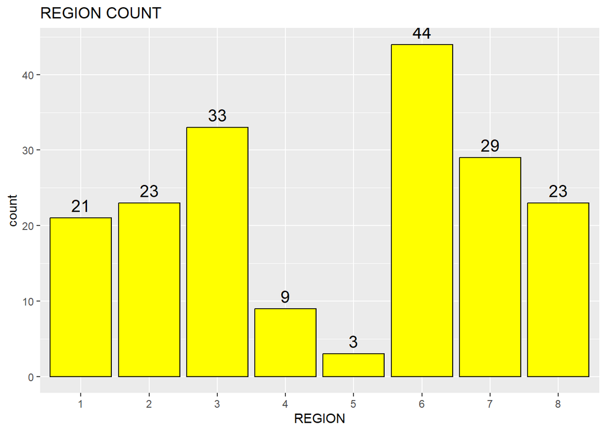

Si può notare come il numero di paesi per regione sia molto variabile, per esempio la 5° ha solamente 3 misure, mentre la 6° ne ha 44. Principalmente le regioni meno popolate sono la 4° e la 5°. Sarà di interesse analizzare altre variabili condizionate alla regione per cerecare eventuali relazioni.

### COUNTRY

La variabile COUNTRY è anch’essa una variabile categorica, ma in questo caso indica il nome del paese quindi ha un’utilità più di “indice” che di effettiva variabile.

### LIFEEXP

La variabile LIFEEXP indica l’aspettativa di vita di un determinato paese, misurata in anni. Andiamo a visualizzare il summary per avere un’idea della distribuzione.

```r
summary(data$LIFEEXP)
```

```
##    Min. 1st Qu.  Median    Mean 3rd Qu.    Max.
##   40.50   59.70   71.00   67.05   75.10   82.30
```

Notiamo come lo spettro dei valori va da 40,5 a 82,3 quindi procediamo con un istogramma per visualizzare la distribuzione di tali dati. Come numero di colonne ci baseremo sul valore calcolato grazie alla formula di Sturges, facendo degli aggiustamenti dove necessario

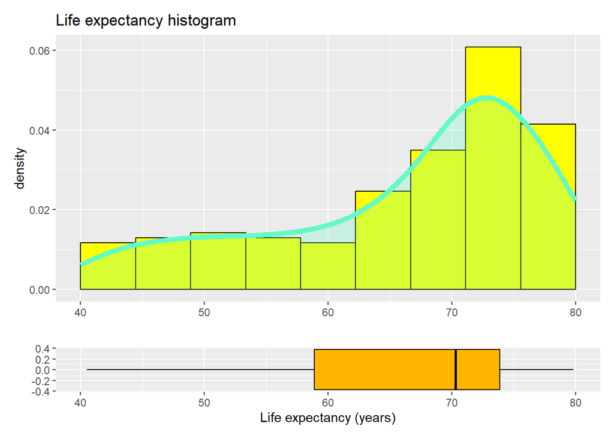

```r
sturges_k = nclass.Sturges(data$LIFEEXP)

p1 =ggplot(data, aes(x = LIFEEXP, y = ..density..)) +
  geom_histogram(bins = sturges_k + 1 , fill = giallo, color = "black", boundary = 0) +
  xlab("") +
  ggtitle("Life expectancy histogram") +
  geom_density(fill = verde_acqua, color = verde_acqua, alpha = 0.25, lwd = 2)+
  xlim(c(40, 80))

p2 = ggplot(data, aes(x = LIFEEXP)) +
  geom_boxplot(fill = arancione, color = "black") +
  xlab("Life expectancy (years)") +
  xlim(c(40, 80))

p1 + p2 + plot_layout(heights = c(6, 1))
```

Dal grafico e dal calcolo della misura dell’asimmetria si può notare come la distribuzione sia leggermente asimmetrica con la frequenza maggiore tra i 70 e gli 80 anni. La mediana della distribuzione è 71 anni, mentre la media è 67,05 anni. Il 50% della distribuzione si trova tra i 59,70 e i 75,1 anni. Per avere una misura dell’assimetria calcoliamo l’indice di skewness.

```r
skewness(data$LIFEEXP)
```

```
## [1] -0.8408485
```

Skeweness negativa indica che la coda della distribuzione è verso sinistra, come in questo caso.

### ILLITERATE

La variabile ILLITERATE indica la percentuale di analfabetismo negli adulti (età > 15 anni). Andiamo a visualizzare il summary.

```r
summary(data$ILLITERATE)
```

```
##    Min. 1st Qu.  Median    Mean 3rd Qu.    Max.    NA's
##    0.20    1.35   10.10   17.69   27.50   76.40      14
```

Sono presenti 14 valori nulli, ovvero meno del 10% del totale. Procediamo con la visualizzazione della distribuzione.

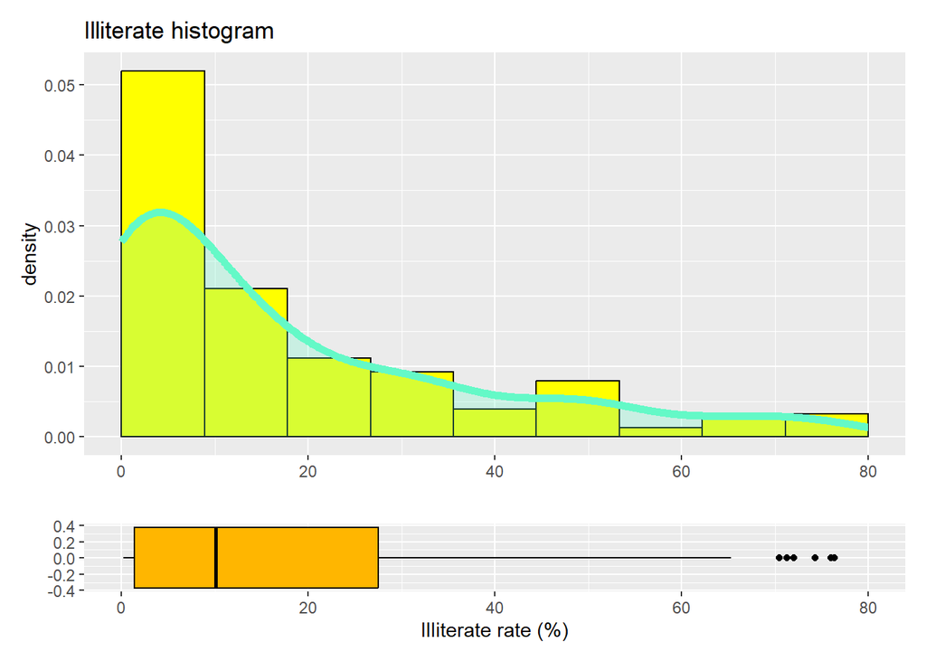

Anche in questo caso notiamo una forte asimmetria, la maggior parte dei paesi ha un tasso di analfabetismo basso, inferiore al 30% mentre pochi paesi hanno un tasso molto alto. I paesi con valori considerati outlier sono (in ordine dal più alto): Burkina Faso, Mali, Chad, Afghanistan, Niger, Guinea. Notiamo come a parte per l’Afghanistan, tutti i paesi con tassi di analfabetismo molto alti facciano parte della regione 6.

```r
skewness(data$ILLITERATE, na.rm = T)
```

```
## [1] 1.308789
```

### POP

```r
summary(data$POP)
```

```
##    Min. 1st Qu.  Median    Mean 3rd Qu.    Max.    NA's
##    0.10    2.45    7.80   35.36   23.60 1313.00       1
```

la presenza dell’unico valore mancante verrà ignorata nell’analisi. Procediamo con la visualizzazione della distribuzione.

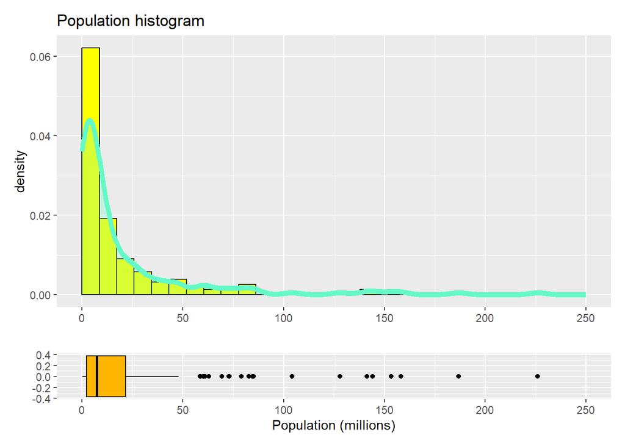

A causa della fortissima dispersione delle misure di Cina e India, abbiamo deciso di tagliare il grafico per rendere leggibili i dati. la distribuzione resta comunque asimmetrica, tornando a evidenziare come la maggior parte dei paesi abbia una popolazione relativamente bassa mentre pochi paesi registrano numerosi abitanti

### FERTILITY

La variabile FERTILITY indica il tasso di fertilità, ovvero il numero di nascite per donna. Andiamo a visualizzare il summary.

```r
summary(data$FERTILITY)
```

```
##    Min. 1st Qu.  Median    Mean 3rd Qu.    Max.    NA's
##    0.90    1.80    2.70    3.19    4.30    7.50       4
```

Procediamo con la visualizzazione.

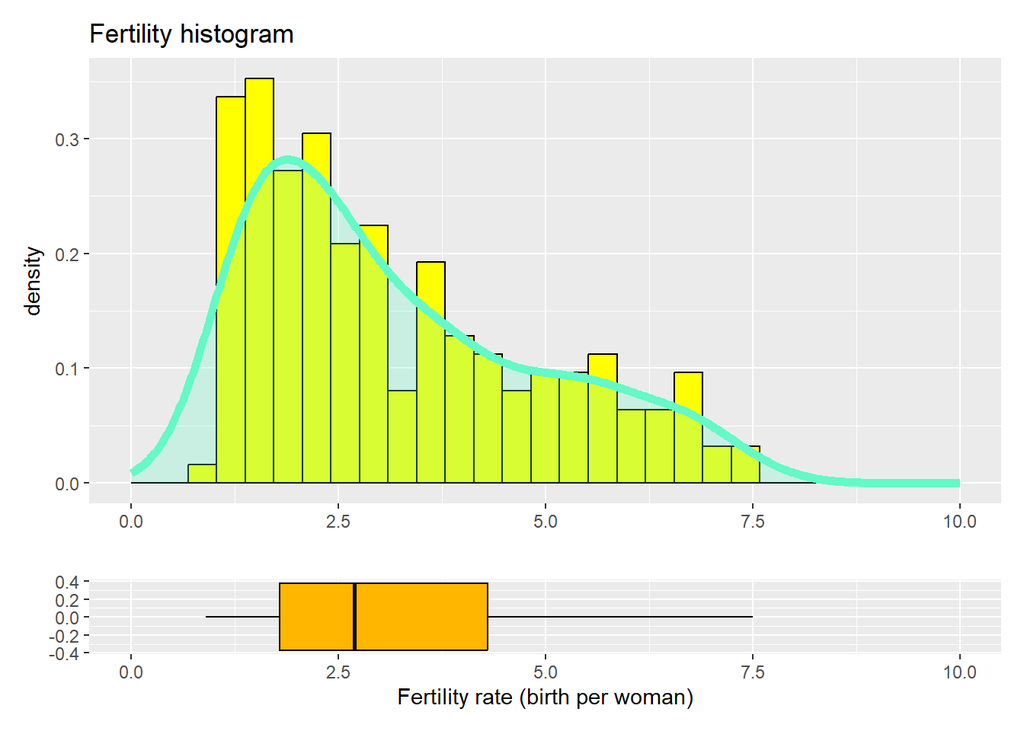

Andiamo anche a calcolare l’indice di assimmetria.

```r
skewness(data$FERTILITY, na.rm = T)
```

```
## [1] 0.7742088
```

### PRIVATEHEALTH

La variabile PRIVATEHEALTH indica la spesa per la samità privata del 2004 misurata in %GDP. Andiamo a visualizzare il summary.

```r
summary(data$PRIVATEHEALTH)
```

```
##    Min. 1st Qu.  Median    Mean 3rd Qu.    Max.    NA's
##   0.300   1.500   2.400   2.517   3.300   8.500       1
```

la presenza dell’unico valore mancante verrà ignorata nell’analisi. Si può già notare come i valori non superino l’8,5% e che questo valore sia già abbastanza lontano dalla maggior parte dei dati guardando il primo e il terzo quartile. Procediamo con la visualizzazione della distribuzione per ricavare ulteriori informazioni.

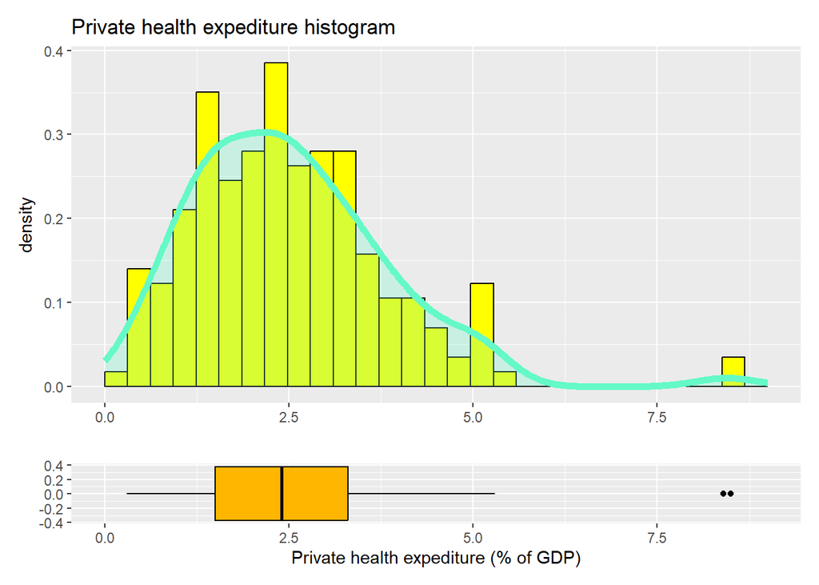

Possiamo notare come la distribuzione sia concentrata principalmente tra 0 e 5% e come la maggior parte dei paesi abbia una spesa inferiore al 3% del GDP. La distribuzione è molto asimmetrica, con una coda verso destra. Vi sono presenti due outliers con i valori 8,5 e 8,4. Identificando questi due paesi si scoprono essere rispettivamente gli Stati Uniti e il Libano, ovvero due paesi in cui il sistema sanitario è altamente privatizzato e frammentato e i servizi medici gratuiti sono quasi inesistenti dunque la spesa privata è di conseguenza molto alta. Ora andiamo a vedere la distribuzione senza quei due valori.

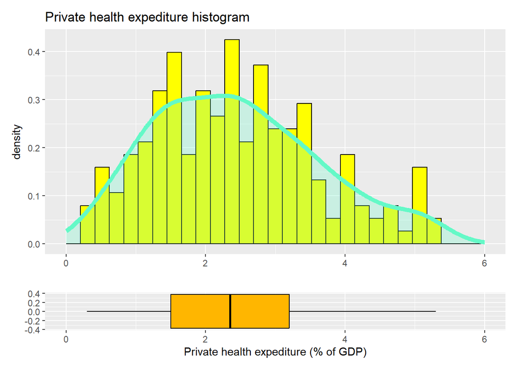

La distribuzione sembrerebbe seguire un andamento normale quindi si prova a confrontarla con una distribuzione normale teorica con media e deviazione standard calcolate sui dati. Per fare ciò si utilizza due grafici molto utili ovvero il quantile-quantile e la funzione di ripartizione empirica che ci permetterà di confrontare le distribuzioni.

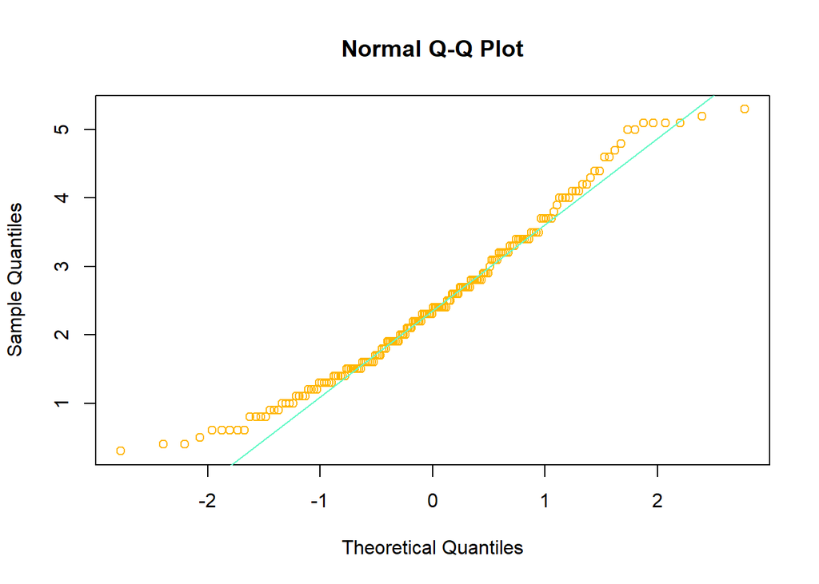

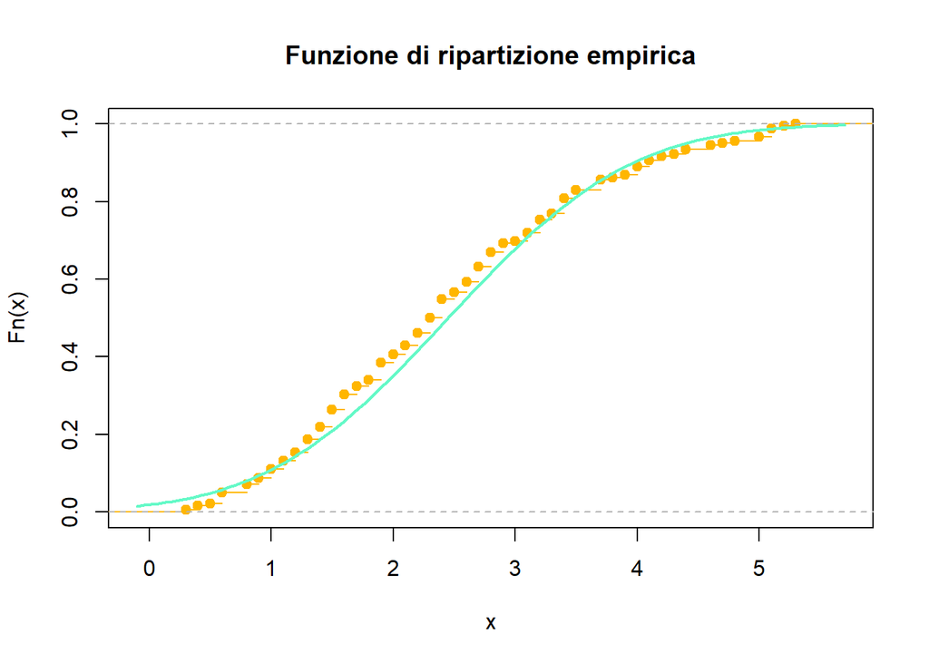

Si nota come entrambi i grafici mostrino una forte aaderenza alla distribuzione gaussiana, sopratutto nella funzione di ripartizione empirica. Questo ci fa pensare che la distribuzione sia effettivamente normale.

### PUBLICEDUCATION

La variabile PUBLICEDUCATION indica la spesa per l’educazione pubblica del 2004 misurata in %GDP. Andiamo a visualizzare il summary.

```r
summary(data$PUBLICEDUCATION)
```

```
##    Min. 1st Qu.  Median    Mean 3rd Qu.    Max.    NA's
##   0.600   3.400   4.600   4.695   5.800  13.400      28
```

Si nota come in questa variabile la quantità relativa di valori nulli sia abbastanza alta (circa il 15% dei dati). Nonostante ciò si può vedere come la maggior parte dei dati presenti sia concentrata intorno ai valori di media e mediana, anch’essi molto vicini. Procediamo con la visualizzazione della distribuzione per ricavare ulteriori informazioni.

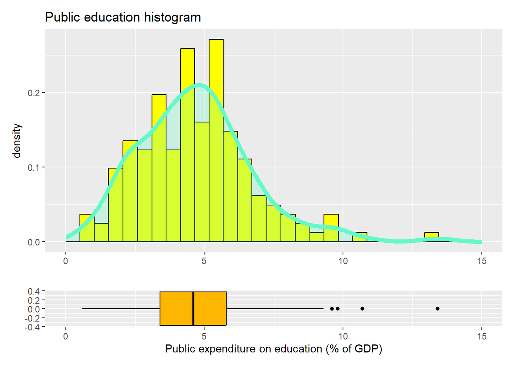

Anche per questa variabile, oltre alla presenza di 4 outliers si può notare la somiglianza ad una distribuzione normale, così come l’altra variabile che misura una percentuale di spesa rispetto al GDP. I 4 outliers sono in ordine Lesotho, Botswana, Cuba, Yemen quindi si può notare come i primi due valori più alti appartengano alla regione 6. Anche qui la distribuzione assomiglia abbastanza ad una normale, quindi si conducono i medesimi test rispetto alla variabile precedente.

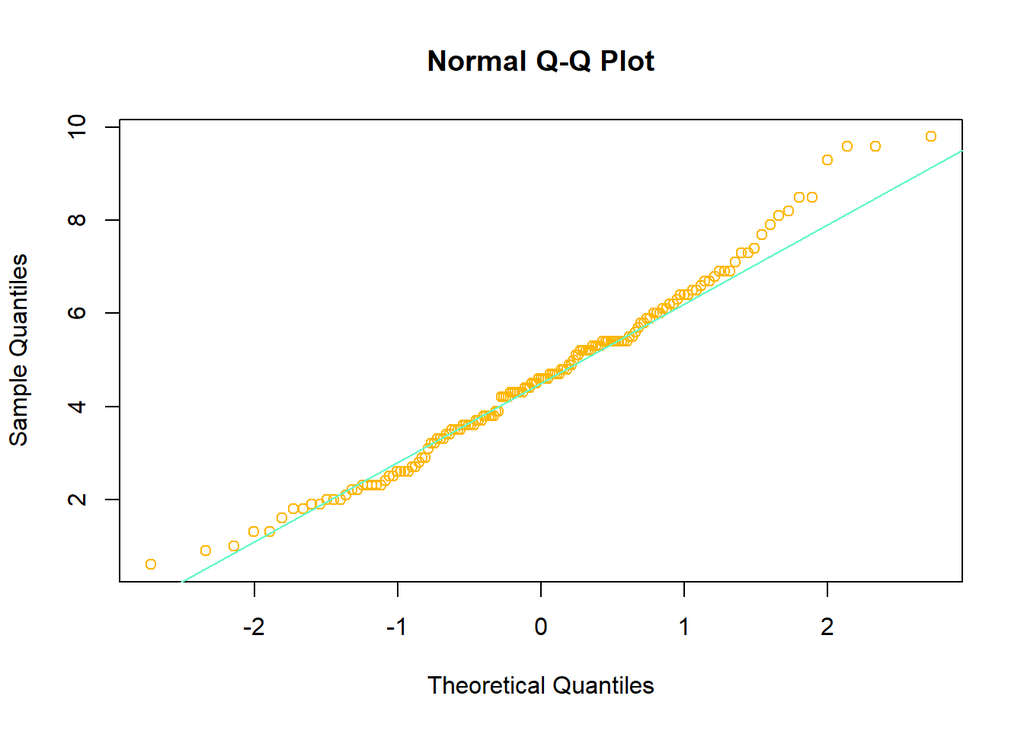

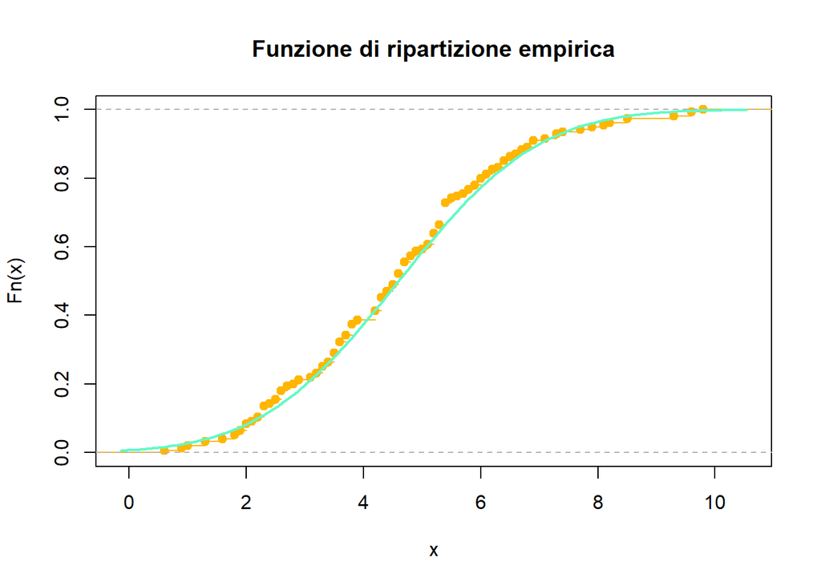

### HEALTHEXPEND

La variabile HEALTHEXPEND indica la spesa sanitaria pro capite del 2004 misurata in USD. Andiamo a visualizzare il summary.

```r
summary(data$HEALTHEXPEND)
```

```
##    Min. 1st Qu.  Median    Mean 3rd Qu.    Max.    NA's
##    15.0   100.5   297.5   718.0   727.0  6096.0       5
```

Già dal summary si può notare come la maggior parte dei dati sia tra i valori 100,5 e 727 nonstante il valore massimo osservato sia di 6096. Questo ci può già far intuire come la distribuzione sarà molto asimmetrica, probabilmente con una lunga coda a destra. Procediamo con la visualizzazione oppure in alternativa il massimo si tratterà di un outlier.

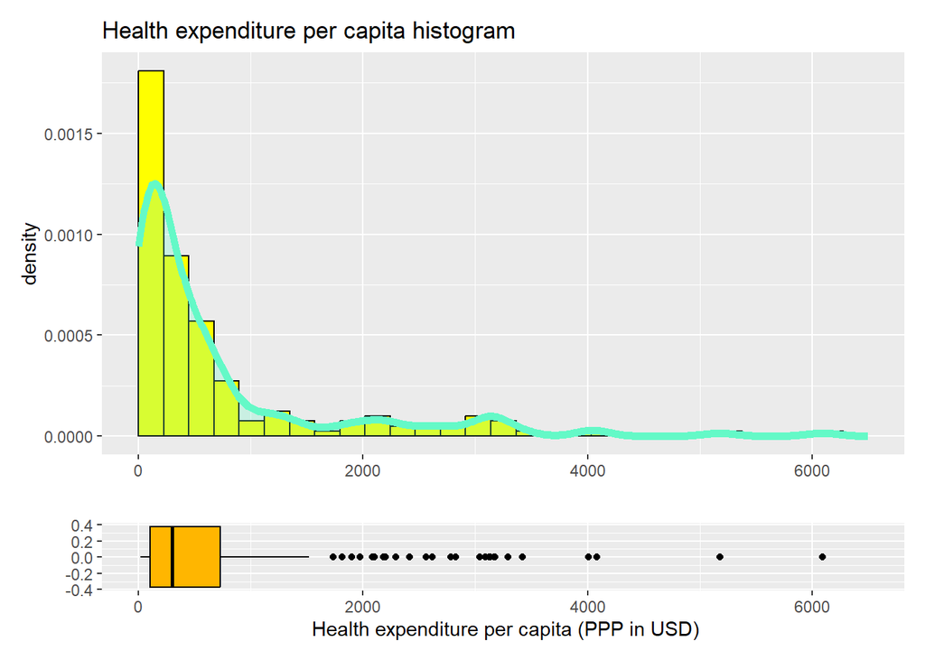

Come avevamo previsto la maggior parte dei dati è concentrata sotto il valore 1000. Il valore più alto osservato corrisponde agli Stati Uniti come ci si può aspettare visto il sistema sanitario in questione seguito dal Lussemburgo e altri paesi europei. Calcoliamo l’indice di skeweness per verificare l’assimetria.

```r
skewness(data$HEALTHEXPEND, na.rm = T)
```

```
## [1] 2.394425
```

Il valore fortemente positivo indica che la coda della distribuzione è verso destra, come previsto.

### BIRTHATTEND

La variabile BIRTHATTEND indica la percentuale di nascite assistite da personale specializzato. Ci si aspetta che nella maggior parte dei paesi questa peprcentuale sia molto alta con pochi paesi in cui essaa è molto bassa. Andiamo a visualizzare il summary.

```r
summary(data$BIRTHATTEND)
```

```
##    Min. 1st Qu.  Median    Mean 3rd Qu.    Max.    NA's
##    6.00   61.00   92.00   78.25   99.00  100.00       7
```

Come ci si aspetta da una misura percentuale, la distribuzione è tra lo 0 e il 100% con una maggiore concentrazione nella parte alta della distribuzione ma con un valore minimo di 6, molto basso per questo tipo di variabile. Procediamo con la visualizzazione della distribuzione. Ci sono comunque 7 valori mancanti che verranno ignorati nell’analisi.

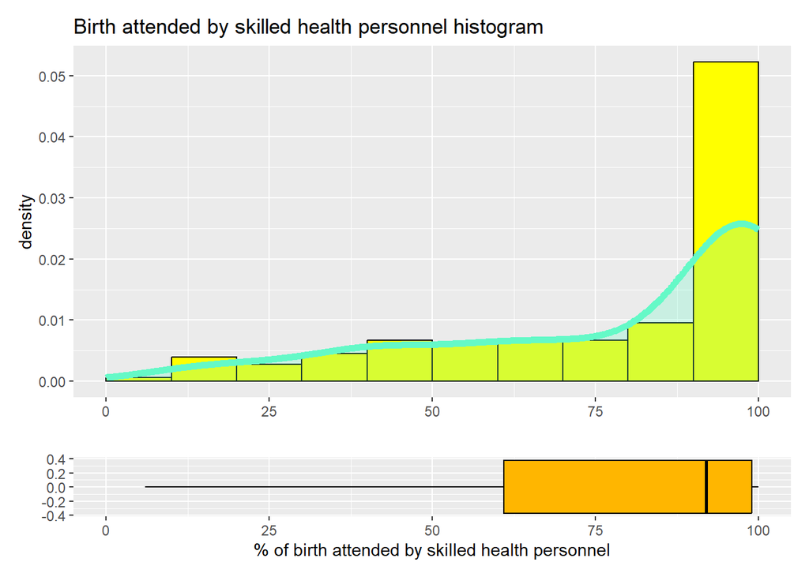

I valori più bassi sono rispettivamente appartenenti alla regione 5 e tre appartengono alla regione 4, regioni che finora non sono mai spiccate particolarmente, sarà interessante cercare correlazioni aggiuntive. Si può dire che la distribuzione riapetti le ipotesi fatte in precedenza in quanto sia prevalentemente concentrata su valori vicini al 100.

### PHYSICIAN

Questa è una variabile che crediamo abbia sicuramente legami con HEALTHEXPEND e PRIVATEHEALTH in quanto i medici presenti in un Paese sono uno degli aspetti principali che vengono considerati quando si parla di spesa medica (pubblica e non). Crediamo che possano esserci correlazioni con LIFEEXP in quanto, si sa, “un medico può salvarti la vita”.

Andiamo a visualizzarne la percentuale di NA.

```r
p_na = sum(is.na(data$PHYSICIAN))/length(data$PHYSICIAN)
p_na
```

```
## [1] 0.01621622
```

Ci troviamo davanti ad una delle variabili più “complete” del dataset, poiché da valore sia all’analisi univariate che alla bivariata che andremo poi ad eseguire con target LIFEEXP. Possiamo ripulire la variabile delle 3 misurazioni mancanti e cominciare l’analisi.

```r
ph = na.omit(data$PHYSICIAN)
summary(ph)
```

```
##    Min. 1st Qu.  Median    Mean 3rd Qu.    Max.
##    2.00   21.25  107.50  146.08  247.00  591.00
```

I valori sono abbastanza ampi e vediamo come il massimo sembri un outlier nei confronti del resto della distribuzione. Questo comportamento comunque non ci stupisce più molto, poiché come abbiamo già notato più volte in questo dataset la presenza di outlier verso destra è solo indice che alcuni Paesi hanno politiche molto più incentrate sulla variabile d’interessa rispetto agli altri. Visualizziamo i grafici

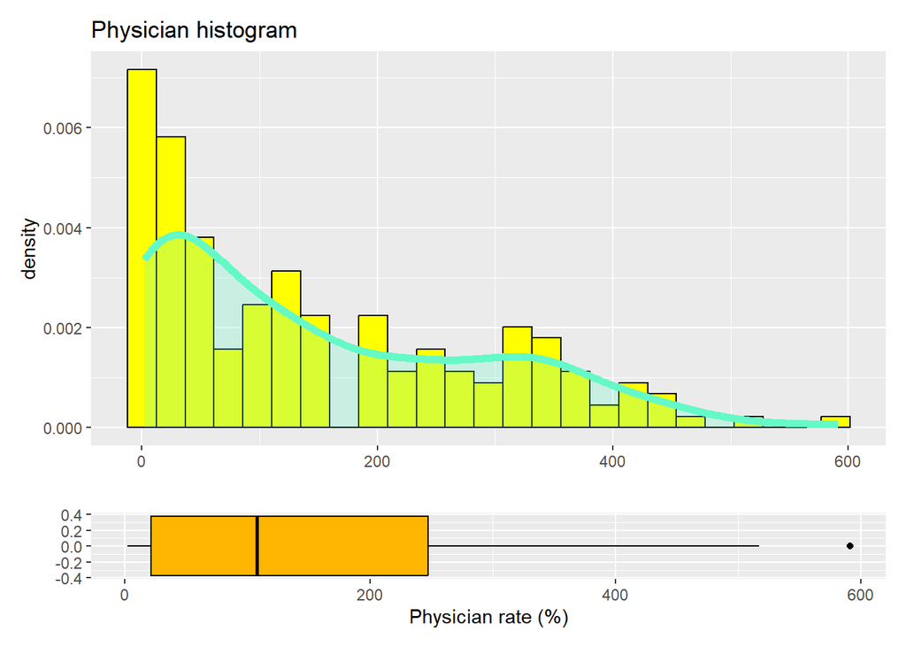

Come previsto il massimo assume il significato di outlier destro per la nostra distribuzione anche se, ugualmente, abbiamo un range di valori molto densi che ricoprono bene l’intero dominio. Abbiamo comunque la maggiore concentrazione schiacciata verso il minimo, ma questa cosa non ci stupisce troppo dopo i risultati ottenuti da HEALTHEXPEND e PRIVATEHEALTH.

### SMOKING

SMOKING potrebbe essere una variabile interessante, poiché, come è noto, il fumo è una delle cause di morte a livello globale, e dunque nell’analisi bivariata con target LIFEEXP ci possiamo aspettare qualcosa di interessante (tuttavia queste sono solo speculazioni a priori). Inoltre ricordiamo che SMOKING presenta il tasso di fumatori solo per la popolazione maschile e soprattutto è molto probabile che appaia come una distribuzione uniforme, poiché il vizio del fumo dovrebbe essere presente in egual modo in tutto il mondo.

Andiamo a visualizzarne la percentuale di NA.

```r
p_na = sum(is.na(data$SMOKING))/length(data$SMOKING)
p_na
```

```
## [1] 0.4756757
```

La percentuale è davvero elevata e questo ci indica un’inaccuratezza della capacità descrittiva reale della distribuzione della variabile. Questo inoltre significa che difficilmente da un’analisi bivariata potremo ottenere risultati soddisfacenti.

```r
sm = na.omit(data$SMOKING)
summary(sm)
```

```
##    Min. 1st Qu.  Median    Mean 3rd Qu.    Max.
##    6.00   24.00   32.00   35.09   47.00   68.00
```

Dai dati sembra cadere l’ipotesi di uniformità della distribuzione, tuttavia media e mediana sembrano sufficientemente vicine e centrali per indicarci un’indice di simmetria vicino a 0(probabilmente leggermente spostato verso sinistra). Calcoliamolo.

```r
idx = skewness(sm)
idx
```

```
## [1] 0.2857299
```

Nonostante la mediana alla sinistra della media l’indice di simmetria ci indica una leggera asimmetria verso destra. Dunque non ci resta che visualizzare il grafico per capire da cosa potrebbe essere dato questo comportamento.

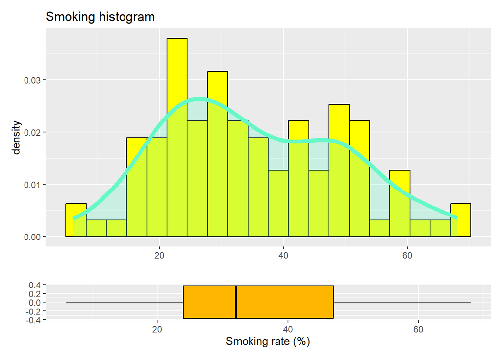

### RESEARCHERS

RESEARCHERS è una variabile interessante, su cui non sappiamo granché esprimerci a priori. Possiamo ipotizzare valori abbastanza bassi e qualche outlier visto che nel mondo i fondi per la ricerca e lo sviluppo sono solitamente sottovalutati ad eccezione di alcuni Paesi che investono grandissimi quantità di denaro.

Valutiamo innanzitutto la percentuale di NA di RESEARCHERS

```r
p_na = sum(is.na(data$RESEARCHERS))/length(data$RESEARCHERS)
p_na
```

```
## [1] 0.5135135
```

Si evince che la percentuale di NA è così elevata da coprire più della metà della variabile. Questo ci indica che l’analisi non sarà esaustiva del vero comportamento della variabile.

```r
rs = na.omit(data$RESEARCHERS)
summary(rs)
```

```
##    Min. 1st Qu.  Median    Mean 3rd Qu.    Max.
##    15.0   127.2   848.0  2034.7  2538.0 45454.0
```

Media e Mediane sufficentemente lontane, range di valori molto vasto e massimo su tutta un’altra scala rispetto al resto. Probabilmente otterremo valori verso destra che ci andranno a rendere difficile la visualizzazione dei dati tramite grafici. Vedremo dunque poi se varrà la pena di circoscrivere l’analisi ad un range minore.

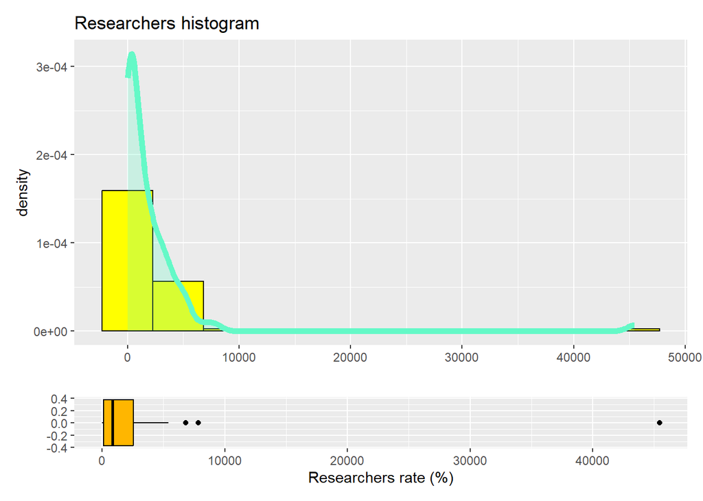

Come previsto, grafici pressoché senza valore per via di 3 outliers principali. Ci proponiamo allora di rivisualizzarli, con l’intento di trovare qualche comportamento interessante, studiando solo i valori minori di una certa soglia. Come soglia scegliamo 5000, che dovrebbe tagliare fuori tutti gli outlier individuati precedentemente.

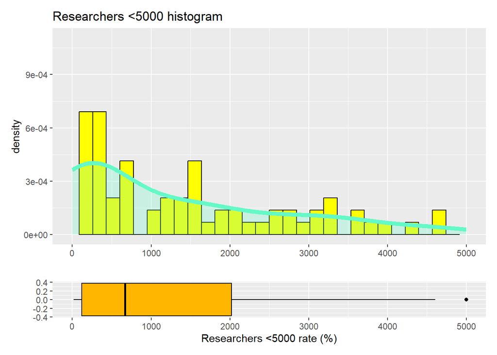

Il grafico ora risulta più comprensibile e (anche considerando gli outlier) si mantiene un comportamento abbastanza stabile di decrescenza. Si nota che intorno alla mediana abbiamo l’unico picco della distribuzione e la coda verso destra decresce ad una velocità pressoché costante. Questo è un comportamento che ci si poteva aspettare valutando le politiche globali sui temi della ricerca e lo sviluppo. Sarebbe interessante valutare questa variabile condizionatamente a REGION per vedere la distribuzione a livello regionale della ricerca e lo sviluppo. Ricordiamo infine nuovamente che la variabile presenta una percentuale di NA così elevata che dobbiamo “prendere con le pinze” le conclusioni che riusciamo ad ottenere.

### GDP

GDP è la variabile che indica il prodotto interno lordo di un Paese, quindi a priori potrei aspettarmi una variabile che presenta dei grandi squilibri (ci sono paesi molto più ricchi e paesi molto più poveri) e sarebbe sicuramente interessante andare a valutare il GDP condizionato a REGION.

Andiamo a valutare la percentuale di NA presentin in GDP.

```r
p_na = sum(is.na(data$GDP))/length(data$GDP)
p_na
```

```
## [1] 0.03783784
```

La percentuale di NA è davvero bassa, volendo verificare esattamente il numero di NA otteniamo:

```r
c_na = sum(is.na(data$GDP))
c_na
```

```
## [1] 7
```

```r
gdp = na.omit(data$GDP)
summary(gdp)
```

```
##     Min.  1st Qu.   Median     Mean  3rd Qu.     Max.
##     0.10     3.55    14.20   247.55   109.28 12416.50
```

Come ci aspettavamo abbiamo un range di valori enormi, e probabilmente, già solo dal summary, possiamo aspettarci che verso il massimo siano presenti alcuni outlier che porteranno problemi nel momento in cui andremo a rappresentare i grafici. Media e Mediana sono completamente diverse e questo è quasi sicuramente dovuto alla presenza di outlier verso la coda destra della distribuzione.

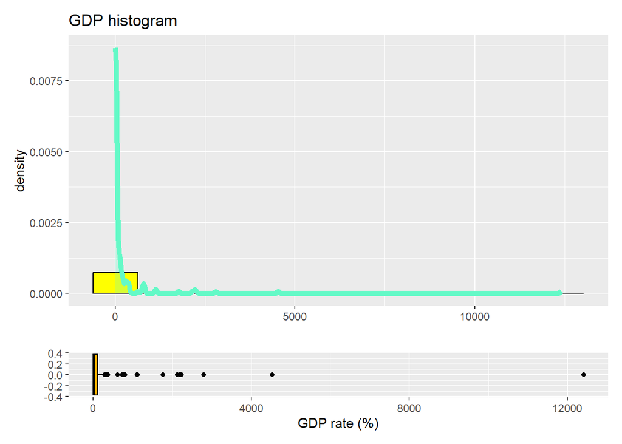

Come previsto la coda destra presenta degli outlier davvero significativi che rendono i nostri grafici pressoché privi di significato. Proviamo allora a rivisualizzarli questa volta considerando solo i dati nel range 0-250 (leggermente sopra la media).

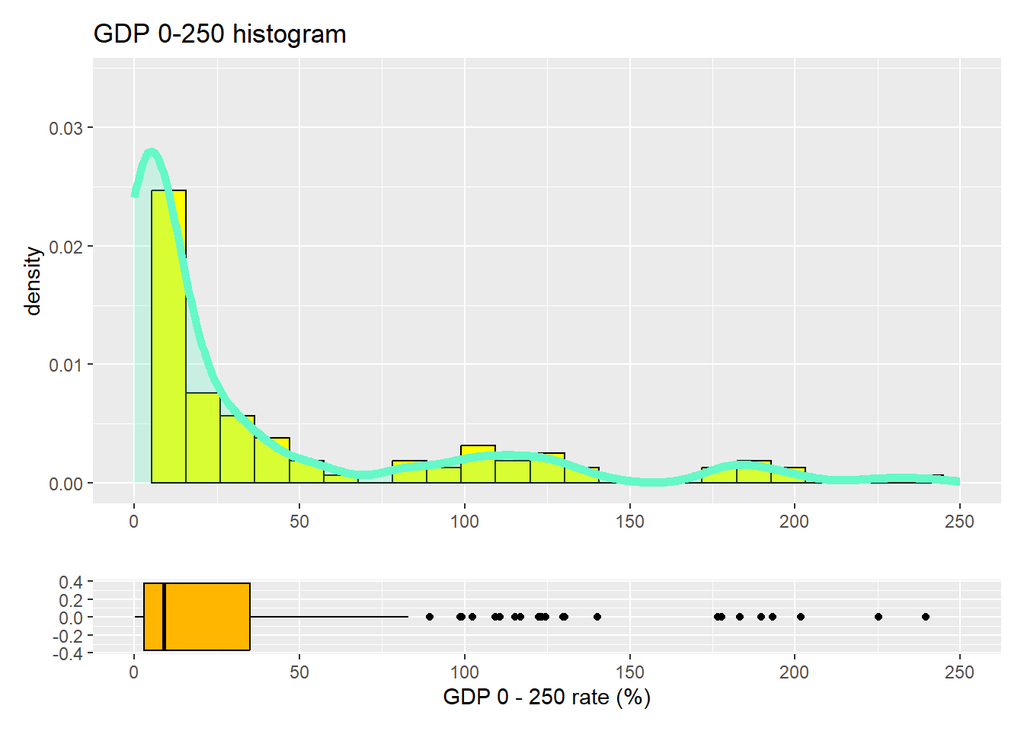

Questa volta otteniamo un grafico già pù comprensibile e da cui possiamo visualizzare informazioni aggiuntive. Comprendiamo infatti come gli outlier presentino dei cluster, probabilmente ad indicare che in realtà lo studio della singola variabile GDP non è molto utile e potrebbe essere di rilievo maggiore lo studio congiunto ad altri fattori, quali potrebbero essere REGION o PRIVATEHEALTH e simili (che sono valutati proprio in termini di %GDP).

### FEMALEBOSS

FEMALEBOSS è la variabile che indica la percentuale di donne che ricoprono posizioni manageriali. A priori ci possiamo aspettare valori leggermente bassi per il retaggio culturale globale sull’argomento.

Andiamo a valutare la percentuale di NA presenti in FEMALEBOSS.

```r
p_na = sum(is.na(data$FEMALEBOSS))/length(data$FEMALEBOSS)
p_na
```

```
## [1] 0.4702703
```

Notiamo che la percentuale è davvero elevata e questo ci indica che l’analisi che faremo sarà poco significativa, nonostante ciò procediamo con la pulizia della variabile e la successiva analisi vera e propria.

```r
fb = na.omit(data$FEMALEBOSS)
summary(fb)
```

```
##    Min. 1st Qu.  Median    Mean 3rd Qu.    Max.
##    2.00   23.25   30.00   29.07   36.75   58.00
```

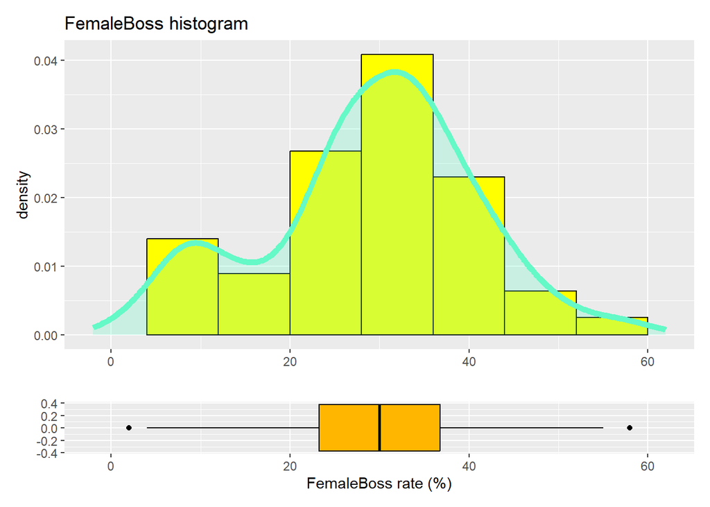

## Analisi Bivariata

##### analisi bivariata con target LIFEEXP

In questo paragrafo ci addentriamo all’interno dello studio bivariato con target LIFEEXP. Grazie all’analisi univariata precedentemente affrontata abbiamo a disposizione informazioni che andremo a sfruttare.

### SELEZIONE DELLE VARIABILI

Come già anticipato all’inizio del documento per l’analisi bivariata non tutte le variabili verranno considerate. In particolare decidiamo di escludere dalla nostra analisi tutte le variabili con un eccessiva percentuale di NA e la variabile COUNTRY, che risulta essere un factor con 185 livelli di tipo stringa diversi e dunque senza un utilità per la previsione di LIFEEXP. Le variabili con eccessivi NA sono RESEARCHERS, SMOKING e FEMALEBOSS. L’assenza di SMOKING è secondo noi una perdita abbastanza importante poiché il fumo è una delle principali cause di morte nel mondo, tuttavia davanti ad una percentuale di NA > 45% e alla presenza di dati che considerano solo gli uomini non possiamo che scartare la variabile.

```r
data = data[,  !(names(data) %in% c("COUNTRY", "SMOKING", "RESEARCHERS", "FEMALEBOSS"))]
```

### CALCOLO DELLE CORRELAZIONI

Procediamo ora a calcolare le correlazioni tra la variabile target ed il resto delle variabili. Dobbiamo ricordarci tuttavia che REGION è un fattore e dunque dovremo escluderla in questo processo. Dopo aver calcolato le correlazioni tra le variabili numeriche procediamo a visualizzarle in un grafico per individuare i valori più interessanti

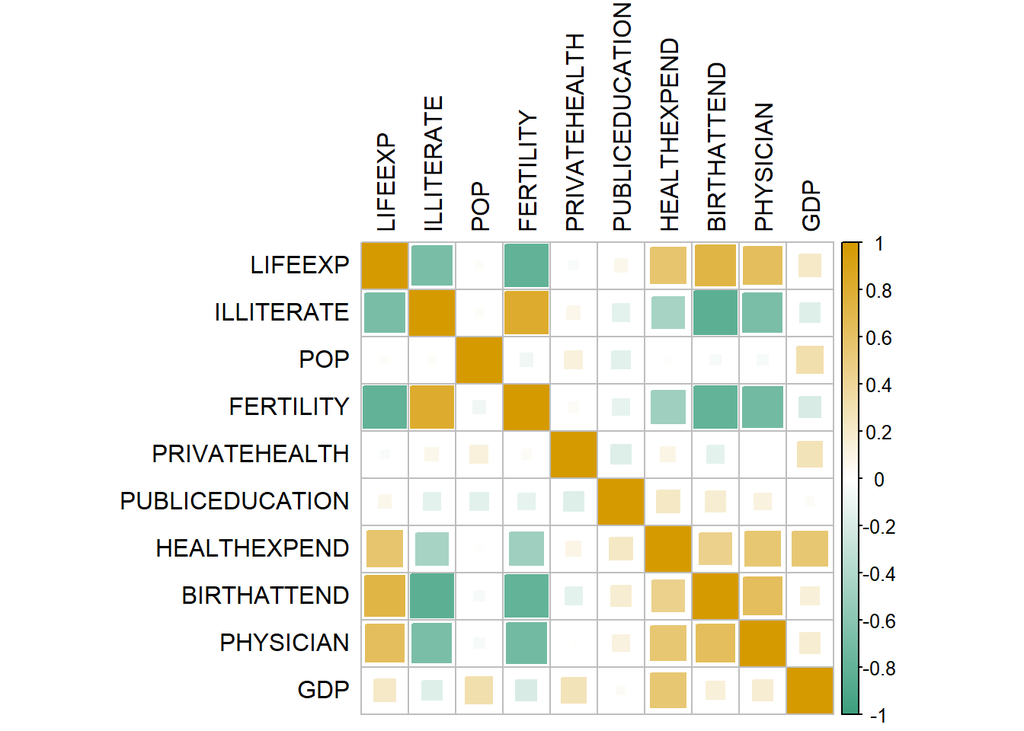

```r
numeric_vars = data[, sapply(data, is.numeric)]
cm = cor(numeric_vars, method = "pearson", use = "pairwise.complete.obs")

corrplot(cm,tl.col = 'black', method = 'square', col = colorRampPalette(c(verde_acqua_scurito, "white", arancione_scurito))(200))
```

```r
correlations = sapply(numeric_vars, function(x) cor(numeric_vars$LIFEEXP, x, use = "pairwise.complete.obs", method = "pearson"))
```

Avendo scelto LIFEEXP come variabile target, per il momento ci interesseremo devi valori di correlazione con essa. Per visualizzarli meglio si decise di fare un grafico a barre in cui mettiamo in ordine per valore di correlazione le variabili relazionate alla target.

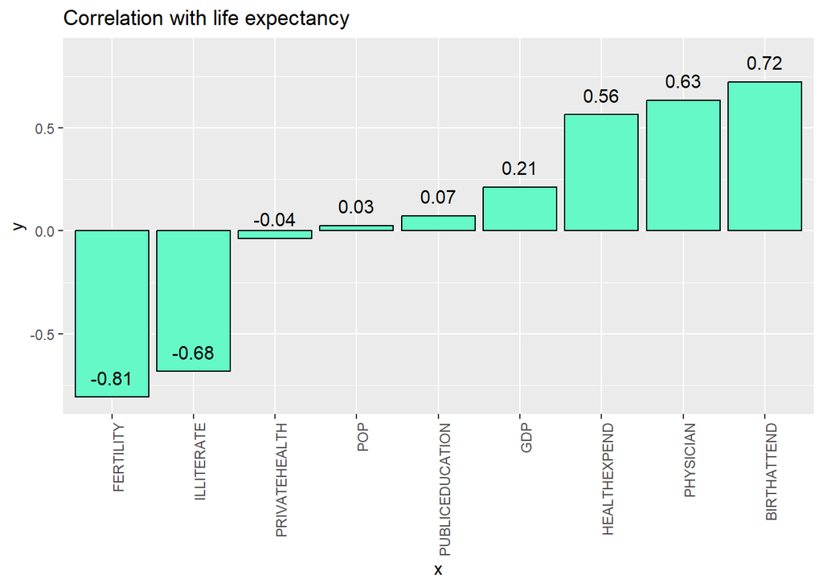

I risultati sono soddisfacenti, poiché abbiamo abbastanza indici di Pearson superiori a 0.5 in modulo. Per quanto riguarda PRIVATEHEALTH, POP e PUBLICEDUCATION, che hanno indici prossimi a 0, decidiamo di non eseguire alcun tipo di analisi bivariata. Possiamo dunque cominciare a tutti gli effetti le nostre analisi bivariate.

### REGION

Poiché la regione è un factor è necessario sviluppare un tipo di analisi completamente diversa rispetto alle altre. Per cominciare andiamo a visualizzare i violin boxplot affiancati.

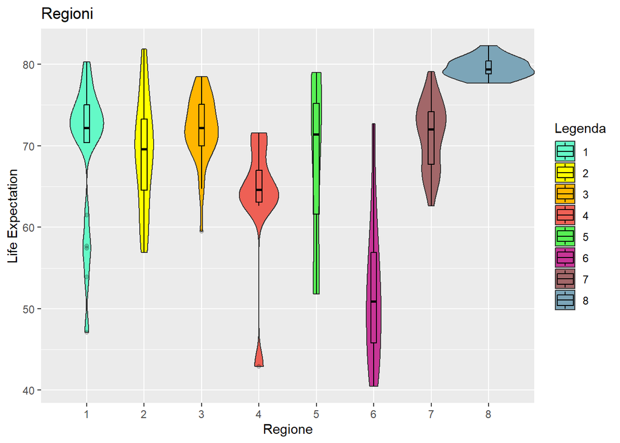

Poiché non sembra esserci indipendenza, eseguiamo un test ANOVA.

```r
test = aov(data$LIFEEXP~rg)
summary(test)
```

```
##              Df Sum Sq Mean Sq F value Pr(>F)
## rg            7  14948  2135.4   49.42 <2e-16 ***
## Residuals   177   7649    43.2
## ---
## Signif. codes:  0 '***' 0.001 '**' 0.01 '*' 0.05 '.' 0.1 ' ' 1
```

### ILLITERATE

La variabile ILLITERATE a differenza di REGION è quantitativa quindi necessita un’analisi diversa rispetto a quest’ultima. Graficamente, visualizziamo la relazione tra le due variabili con uno scatter-plot. La variabile ILLITERATE presenta 14 valori mancanti

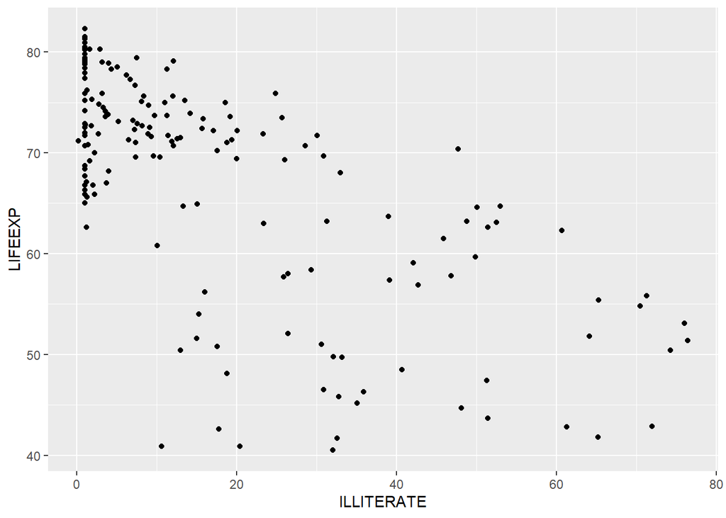

Nel grafico notiamo una prevalenza di due comportamenti delle osservazioni: una parte è concentrata su valori vicini allo 0 di ILLITERATE mentre gli altri sono distribuiti in maniera sparsa ma con una tendenza decresente, a conferma del valore negativo dell’indice di correlazione calcolato in precedenza. Data questa tendenza ci aspettiamo una devianza dei residui abbastanza elevata. Essendo il modulo dell’indice di correlazione alto, proviamo ad analizzare la relazione tra ILLITERATE e LIFEEXP

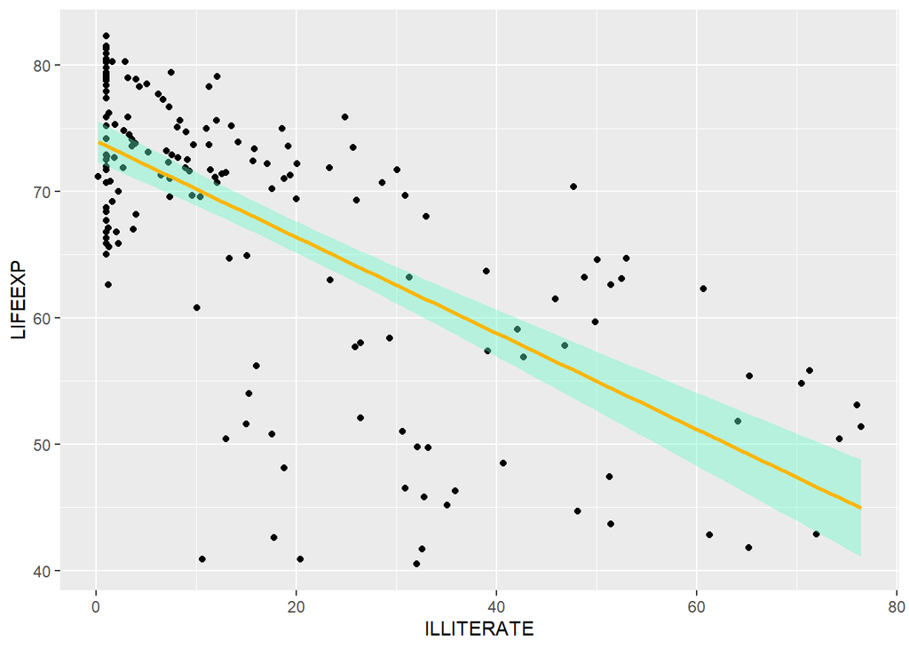

```r
summary(model)
```

```
##
## Call:
## lm(formula = LIFEEXP ~ ILLITERATE, data = data)
##
## Residuals:
##     Min      1Q  Median      3Q     Max
## -29.077  -4.268   1.953   5.884  14.532
##
## Coefficients:
##             Estimate Std. Error t value Pr(>|t|)
## (Intercept) 74.00781    0.83264   88.88   <2e-16 ***
## ILLITERATE  -0.38028    0.03136  -12.13   <2e-16 ***
## ---
## Signif. codes:  0 '***' 0.001 '**' 0.01 '*' 0.05 '.' 0.1 ' ' 1
##
## Residual standard error: 8.121 on 169 degrees of freedom
##   (14 osservazioni eliminate a causa di valori mancanti)
## Multiple R-squared:  0.4653, Adjusted R-squared:  0.4622
## F-statistic: 147.1 on 1 and 169 DF,  p-value: < 2.2e-16
```

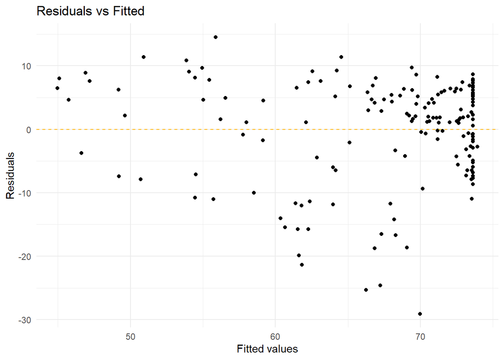

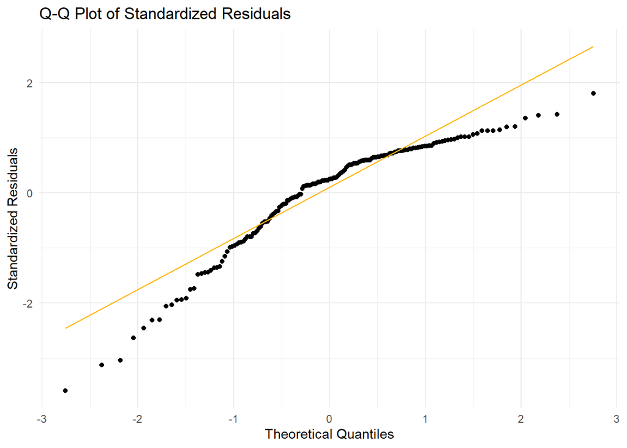